# MLM Plotting

Danny Forster

12/29/2020

```r
library(dplyr)
library(lmerTest)
library(ggplot2)
library(sjPlot)
sjPlot::set_theme(base = theme_bw())
```

## Use This Guide! (especially for lmer objects)

This is a guide that is designed to be your resource for making plots from multilevel models. You can use this as a starting point for visualizing your plots in a reliable way. If you want to learn more about touching up your plots to make them more visually appealing (for a publication, poster, or presentation), then you should read more on using ggplot2. You can find a cheat sheet here: https://www.rstudio.com/wp-content/uploads/2016/11/ggplot2-cheatsheet-2.1.pdf

Feel free to provide feedback so that this can serve as a useful and reliable guide for years to come. I have included what I think is sufficient annotation; however, if you believe anything is unclear, or you can think of a way to make the descriptions/explanations better, please help!

Update December 29, 2020: Special thanks to Daniel Eggelmann for prompting me to update the functions from `sjPlot`!

## Data Background

These data were generated for a course on multilevel modeling in the Department of Psychology at University of Miami.

This guide will use the data set from probset4, since it has a diverse set of properties (e.g., non-linearity) that we would like to capture.

```r
probset4 <- read.csv("probset4.csv", header = T, fileEncoding = "UTF-8-BOM")

probset4 <- probset4 %>%
  group_by(ID) %>%
  mutate(avgARS = mean(ARS)) %>%
  mutate(cwcARS = ARS - avgARS)

probset4$gmcARS <- probset4$avgARS - mean(probset4$avgARS)

probset4$age0 <- probset4$AGE - min(probset4$AGE)

probset4$ageP1 <- ifelse(probset4$age0 <= 8, probset4$age0, 8)

probset4$ageP2 <- ifelse(probset4$age0 <= 8, 0, probset4$age0 - 8)
```

## Approaching Plots

Often times the code for plotting can get messy. To clean things up and clearly separate what features we are adding to our plots, you will probably encounter two different approaches.

Approach 1: Creating an object, then adding features to the object

```r
base.plot <- ggplot(dataName, aes(x = x, y = y, group = cluster))
base.plot + geom_line()
```

Approach 2: Creating a single plot, without any intermediate objects, but each feature is separated by a new line of code.

```r
ggplot(dataName, aes(x = x, y = y, group = cluster)) +
  geom_line()
```

When displaying code incrementally, it is often easier to use Approach 1, since you do not need to read through the same lines of code multiple times. Instead, you simply see an object, which was generated with code you already know, with some added features.

I would also recommend Approach 1 for your own models because if you want to make changes to any individual step, any errors you make in that process will be isolated, so you can easily trace where you are having problems.

## Raw Data

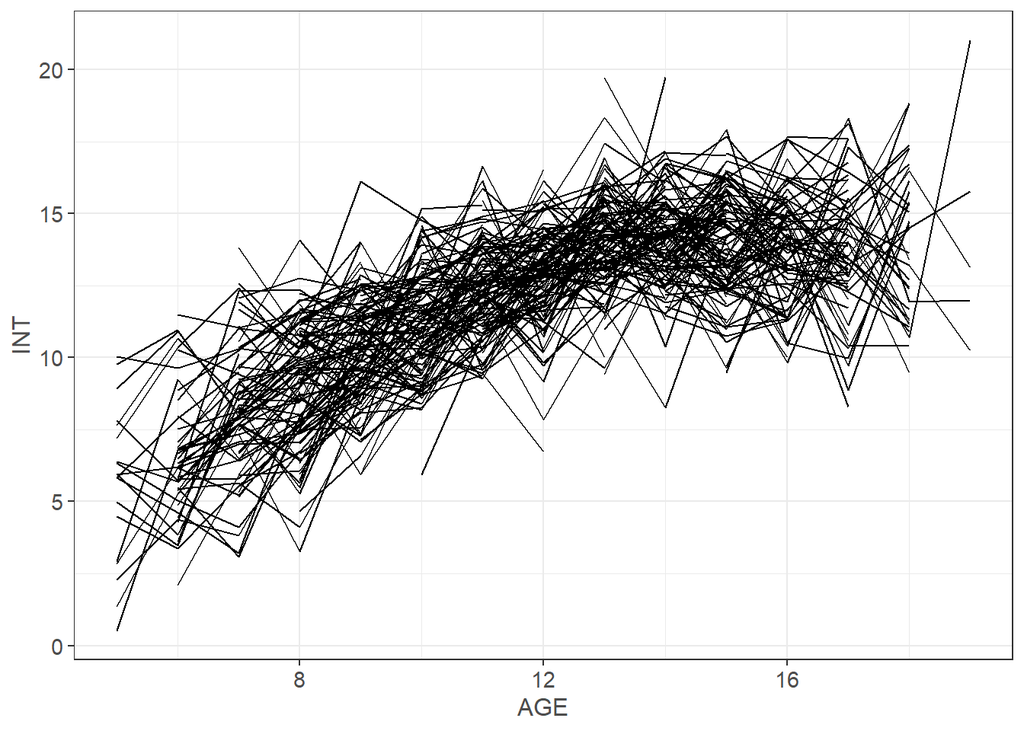

```r
base.plot <- ggplot(probset4, aes(x = AGE, y = INT, group = ID))
base.plot + geom_line()
```

This shows a clear non-linear relationship. Since this data was generated from a piecewise model, we will continue this example with the piecewise model.

## Diagnostic Plots

You need to first build your model to view your residuals. Residuals are the distance between the observed and expected values, so this relies on the predict() function. There are also random effect estimates when you have random intercepts and slopes, which will rely on the ranef() function.

```r
model <- lmer(INT ~ ageP1 + ageP2 + cwcARS + gmcARS + SEX + ageP1:cwcARS + ageP2:cwcARS + ageP1:gmcARS + ageP1:SEX + (1 + ageP1 + ageP2 | ID), data = probset4)
summary(model)
```

```
## Linear mixed model fit by REML. t-tests use Satterthwaite's method [
## lmerModLmerTest]
## Formula: INT ~ ageP1 + ageP2 + cwcARS + gmcARS + SEX + ageP1:cwcARS +
##     ageP2:cwcARS + ageP1:gmcARS + ageP1:SEX + (1 + ageP1 + ageP2 |      ID)
##    Data: probset4
##
## REML criterion at convergence: 4873.5
##
## Scaled residuals:
##     Min      1Q  Median      3Q     Max
## -3.5107 -0.6248  0.0447  0.6314  3.7544
##
## Random effects:
##  Groups   Name        Variance Std.Dev. Corr
##  ID       (Intercept) 0.580571 0.76195
##           ageP1       0.009479 0.09736  -0.77
##           ageP2       0.003813 0.06175   0.51  0.16
##  Residual             2.089865 1.44564
## Number of obs: 1308, groups:  ID, 300
##
## Fixed effects:
##                Estimate Std. Error         df t value Pr(>|t|)
## (Intercept)     4.30948    0.20162   99.77947  21.374  < 2e-16 ***
## ageP1           1.22347    0.03292  158.74033  37.170  < 2e-16 ***
## ageP2          -0.03682    0.04084  230.20050  -0.902   0.3682
## cwcARS          0.41094    0.20693 1051.59911   1.986   0.0473 *
## gmcARS         -1.10448    0.17411  129.70817  -6.343 3.44e-09 ***
## SEX             3.74009    0.27911  115.75695  13.400  < 2e-16 ***
## ageP1:cwcARS   -0.02208    0.03577 1084.93308  -0.617   0.5372
## ageP2:cwcARS    0.56144    0.05677 1032.39992   9.890  < 2e-16 ***
## ageP1:gmcARS    0.20853    0.02876  212.17164   7.252 7.57e-12 ***
## ageP1:SEX      -0.46331    0.04429  177.40236 -10.462  < 2e-16 ***
## ---
## Signif. codes:  0 '***' 0.001 '**' 0.01 '*' 0.05 '.' 0.1 ' ' 1
##
## Correlation of Fixed Effects:
##             (Intr) ageP1  ageP2  cwcARS gmcARS SEX    agP1:cARS aP2:AR
## ageP1       -0.921
## ageP2        0.164 -0.303
## cwcARS      -0.026  0.023 -0.003
## gmcARS      -0.093  0.080 -0.007 -0.038
## SEX         -0.697  0.622  0.018  0.032  0.034
## agP1:cwcARS  0.020 -0.017  0.003 -0.926  0.031 -0.023
## agP2:cwcARS -0.001 -0.001  0.005  0.322 -0.009  0.001 -0.523
## agP1:gmcARS  0.076 -0.062 -0.015  0.034 -0.920 -0.027 -0.027     0.010
## ageP1:SEX    0.640 -0.664 -0.030 -0.027 -0.028 -0.927  0.018     0.002
##             agP1:gARS
## ageP1
## ageP2
## cwcARS
## gmcARS
## SEX
## agP1:cwcARS
## agP2:cwcARS
## agP1:gmcARS
## ageP1:SEX    0.030
## convergence code: 0
## Model failed to converge with max|grad| = 0.0193472 (tol = 0.002, component 1)
```

```r
# Creating level 1 standardized residuals

probset4$predict <- predict(model)

probset4$resid <- probset4$INT - probset4$predict

probset4$zresid <- (probset4$resid - mean(probset4$resid))/sd(probset4$resid)

# Creating level 2 random effects

randeff <- ranef(model)$ID

names(randeff) <- c("u0", "u1", "u2") # Random intercept, random slope for P1, random slope for P2
randeff$ID <- rownames(randeff)

probset4 <- merge(probset4, randeff, by="ID")
```

### Level 1 Residuals

#### Normality

To assess normality, just make a histogram of the level 1 residuals

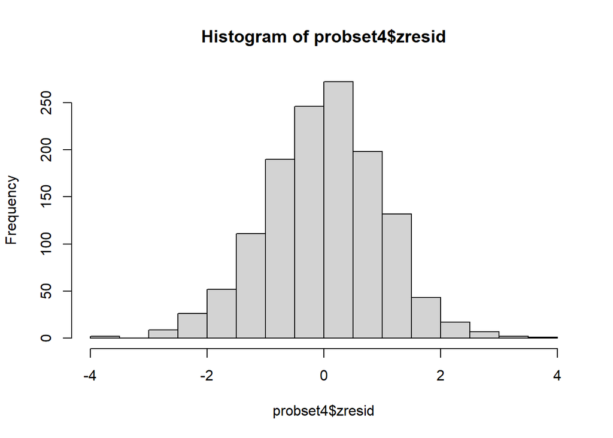

```r
hist(probset4$zresid)
```

#### Heteroscedasticity

To assess heteroscedasticity, plot residuals against predictors

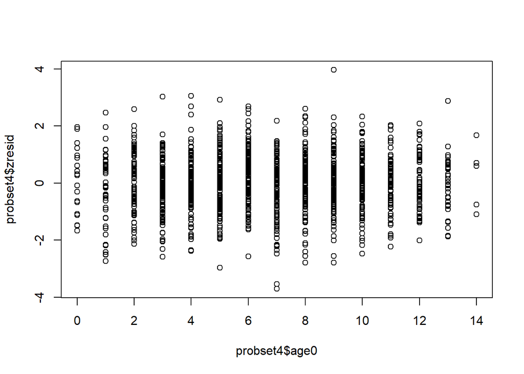

```r
plot(probset4$zresid ~ probset4$age0)
```

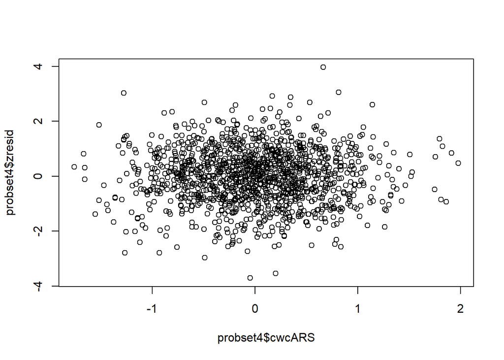

```r
plot(probset4$zresid ~ probset4$cwcARS)
```

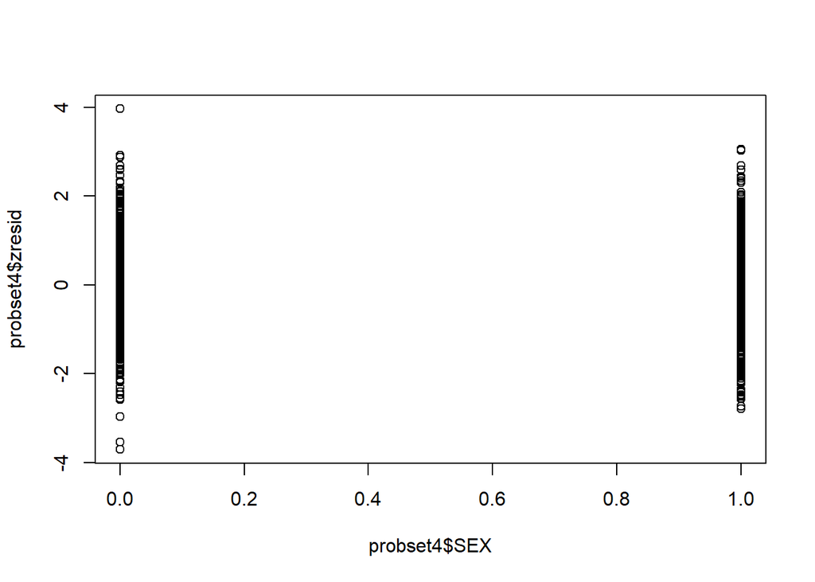

```r
plot(probset4$zresid ~ probset4$SEX)
```

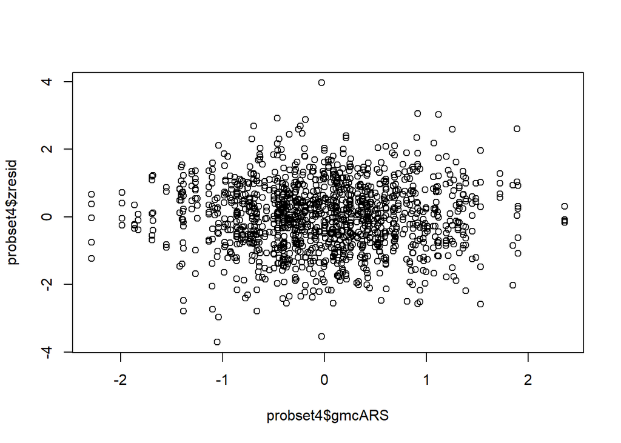

```r
plot(probset4$zresid ~ probset4$gmcARS)
```

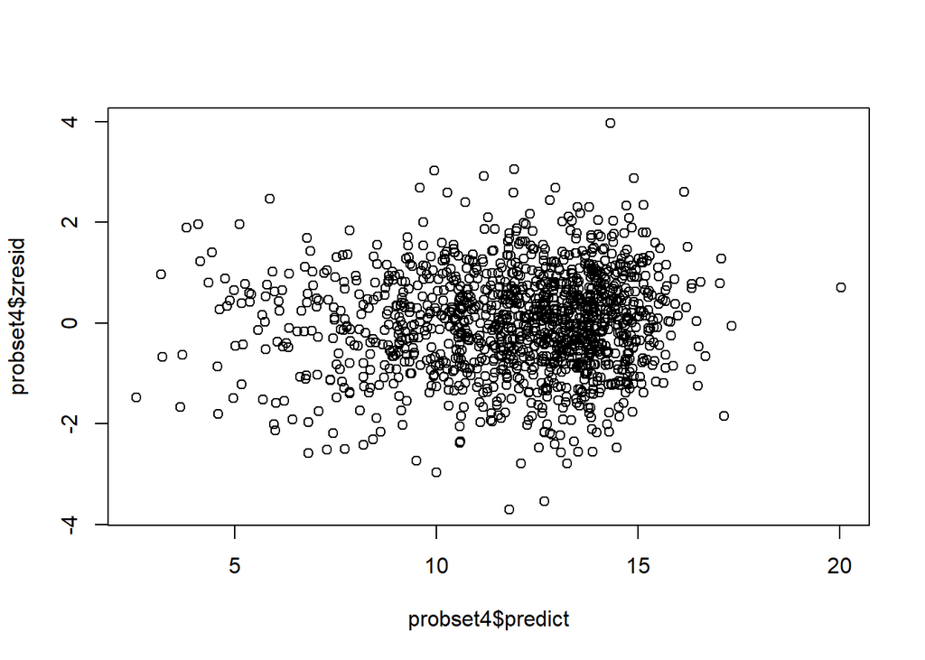

```r
plot(probset4$zresid ~ probset4$predict)
```

### Level 2 Residuals

#### Normality

To assess normality, make histograms of u0, u1, and u2

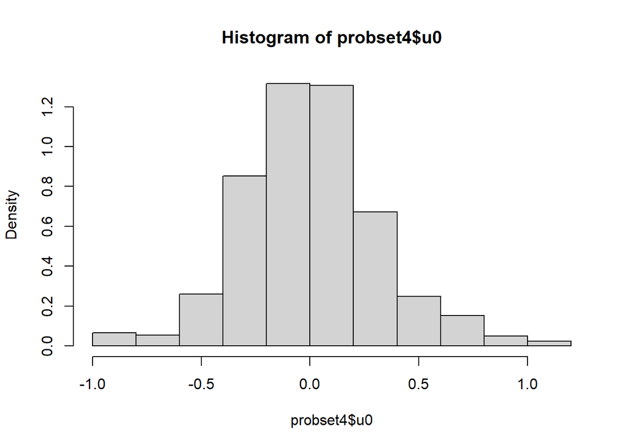

```r
hist(probset4$u0, prob = T)
```

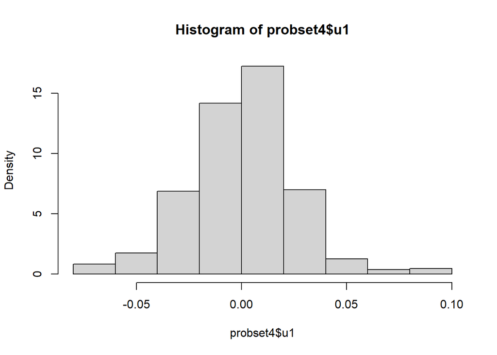

```r
hist(probset4$u1, prob = T)
```

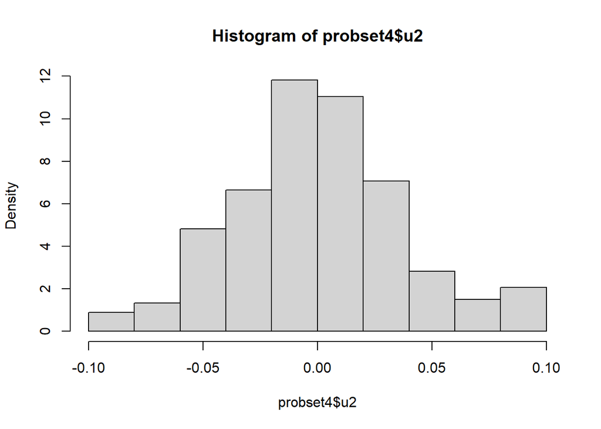

```r
hist(probset4$u2, prob = T)
```

To assess heteroscedasticity, plot u0, u1, and u2 against predictors

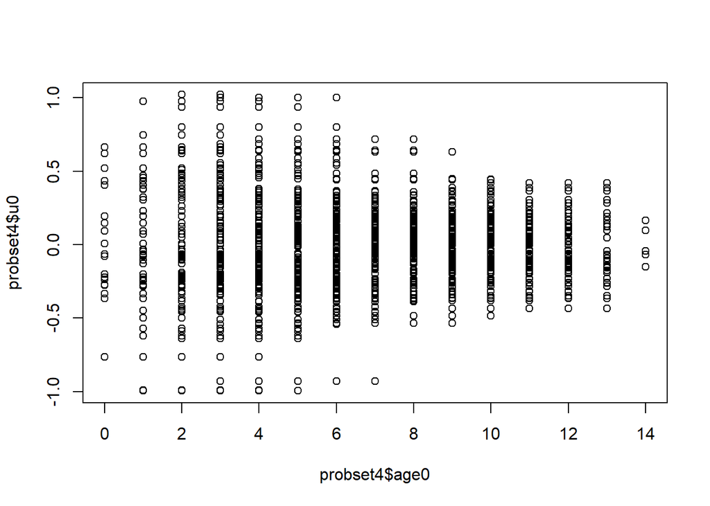

```r
# Random Intercepts
plot(probset4$u0 ~ probset4$age0)
```

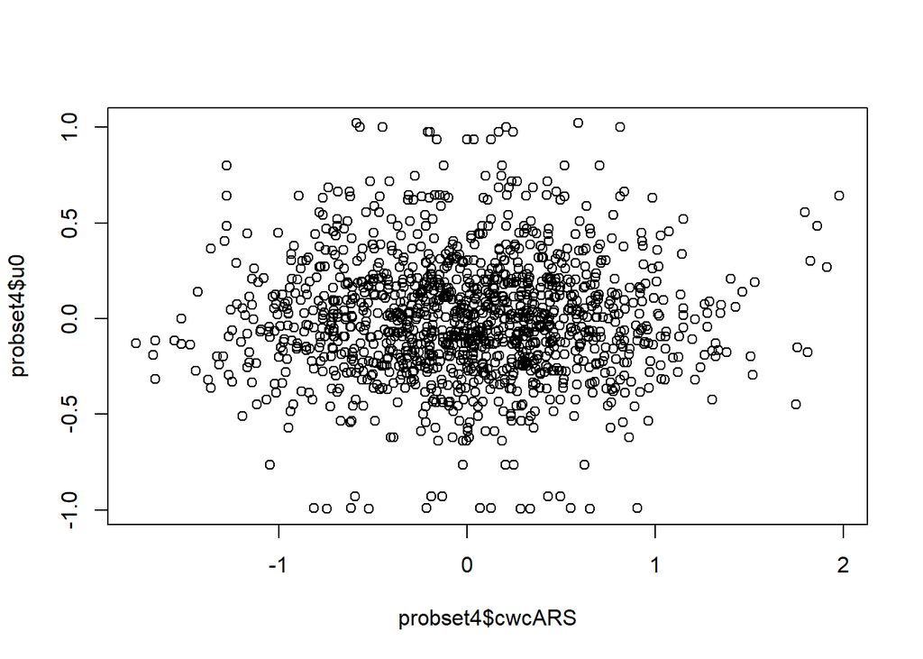

```r
plot(probset4$u0 ~ probset4$cwcARS)
```

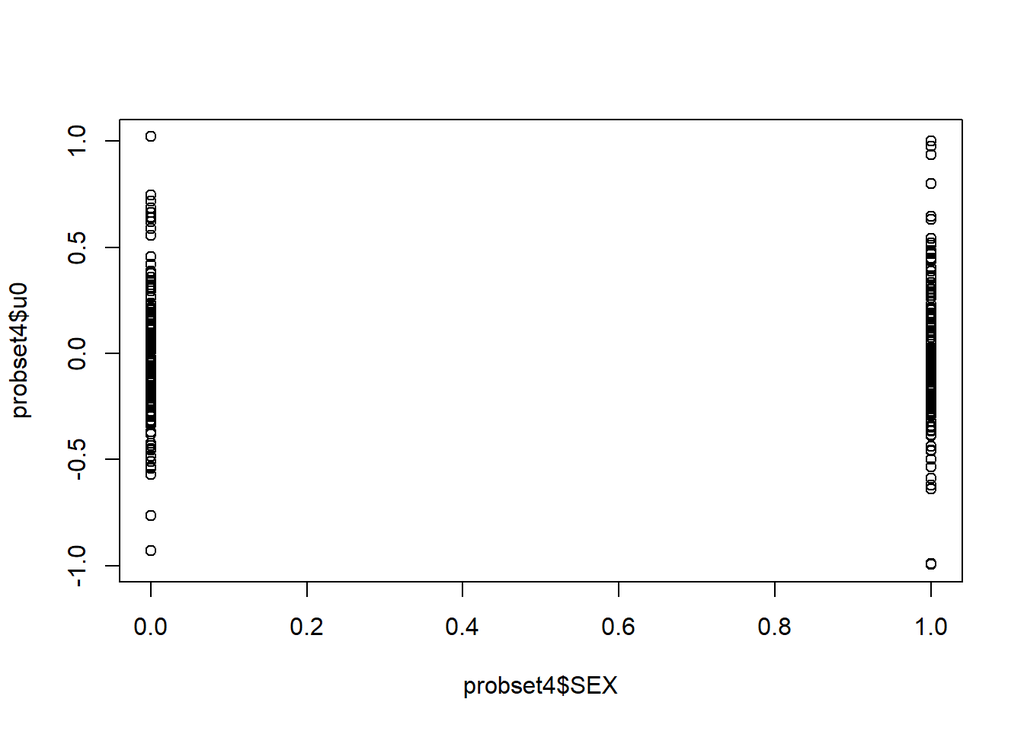

```r
plot(probset4$u0 ~ probset4$SEX)
```

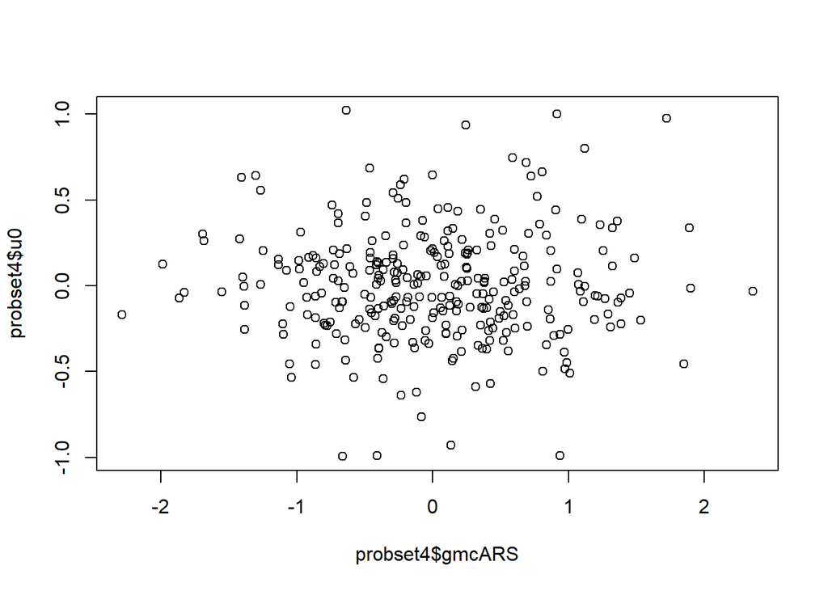

```r
plot(probset4$u0 ~ probset4$gmcARS)
```

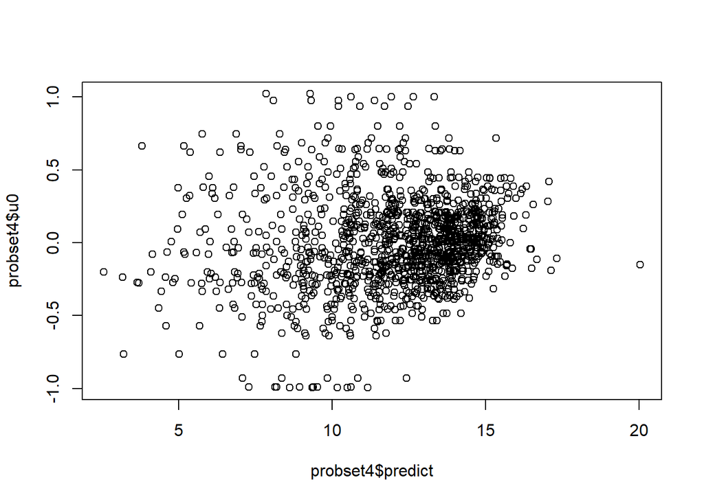

```r
plot(probset4$u0 ~ probset4$predict)
```

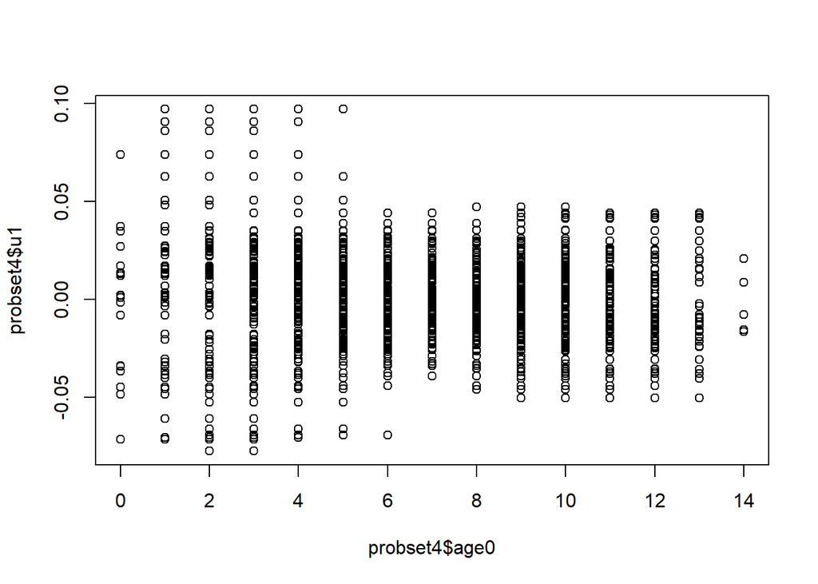

```r
# Random slope (piece 1)

plot(probset4$u1 ~ probset4$age0)
```

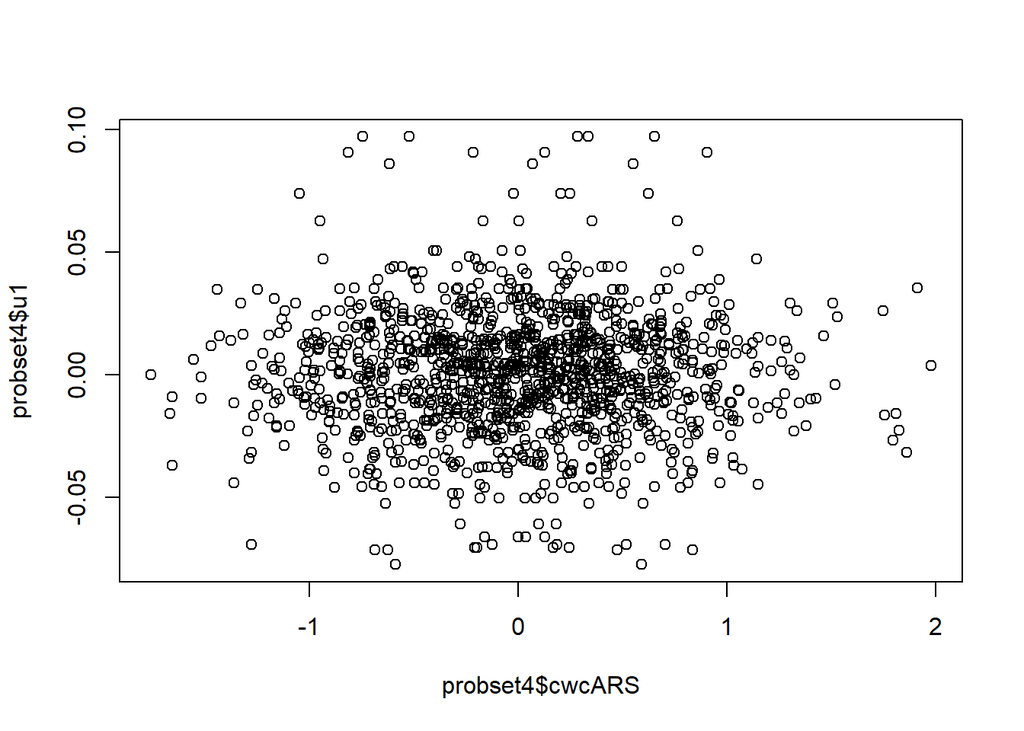

```r
plot(probset4$u1 ~ probset4$cwcARS)
```

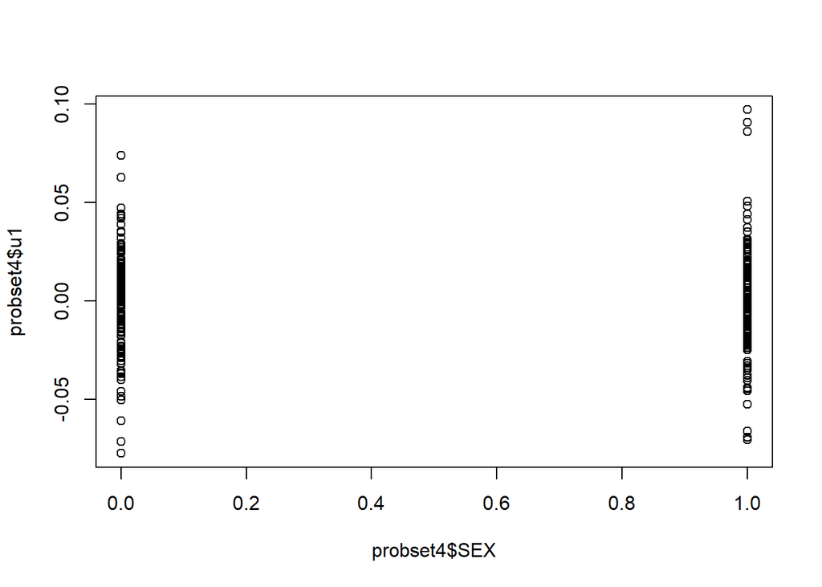

```r
plot(probset4$u1 ~ probset4$SEX)
```

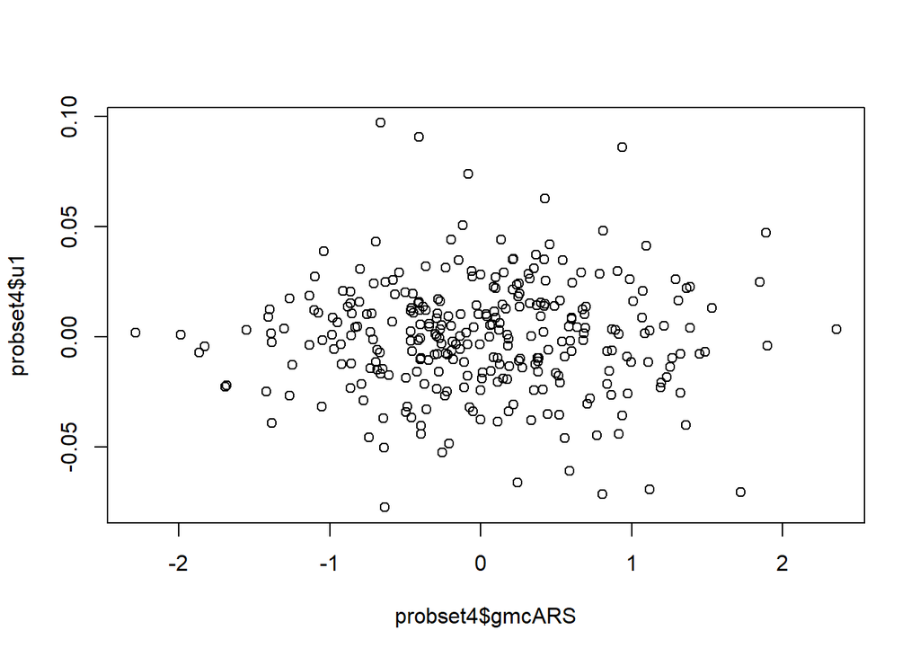

```r
plot(probset4$u1 ~ probset4$gmcARS)
```

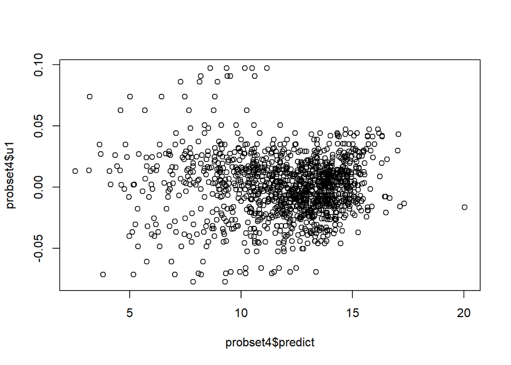

```r
plot(probset4$u1 ~ probset4$predict)
```

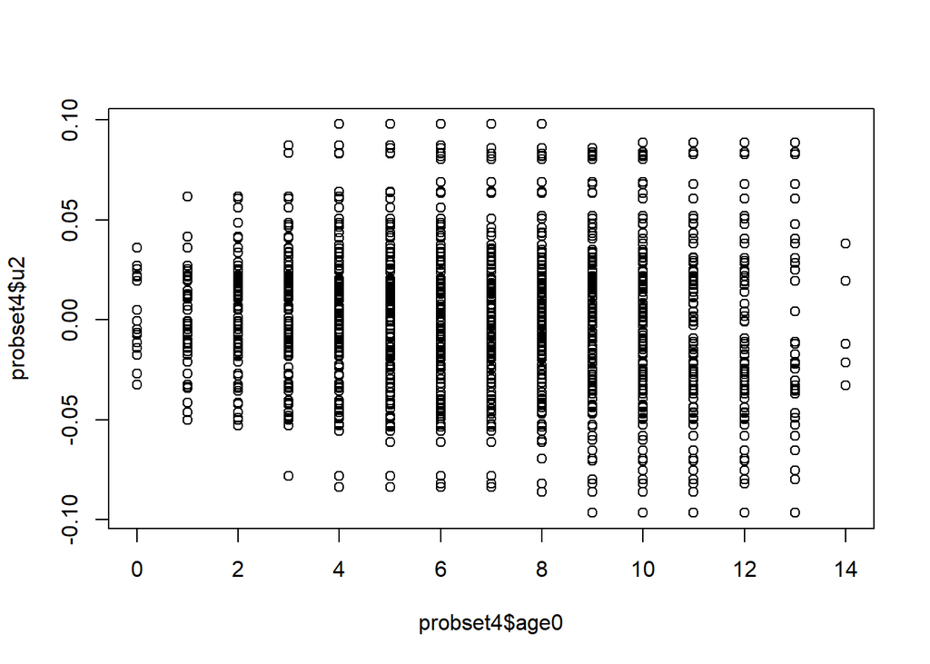

```r
# Random Slope (piece 2)

plot(probset4$u2 ~ probset4$age0)
```

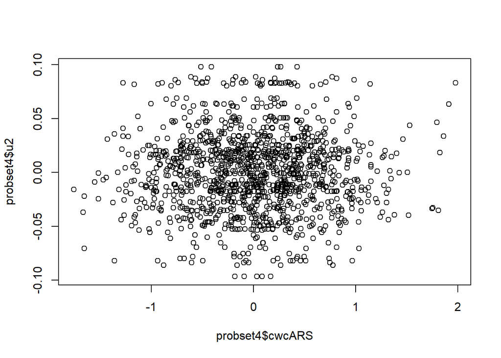

```r
plot(probset4$u2 ~ probset4$cwcARS)
```

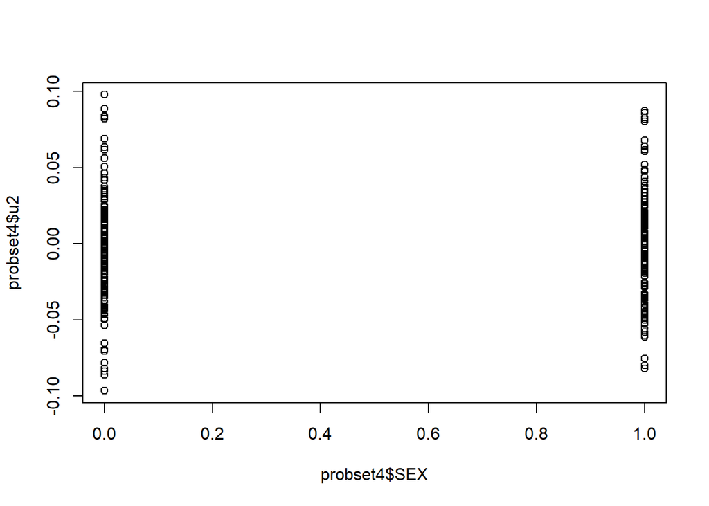

```r
plot(probset4$u2 ~ probset4$SEX)
```

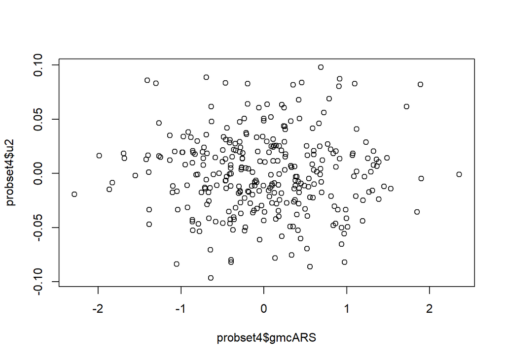

```r
plot(probset4$u2 ~ probset4$gmcARS)
```

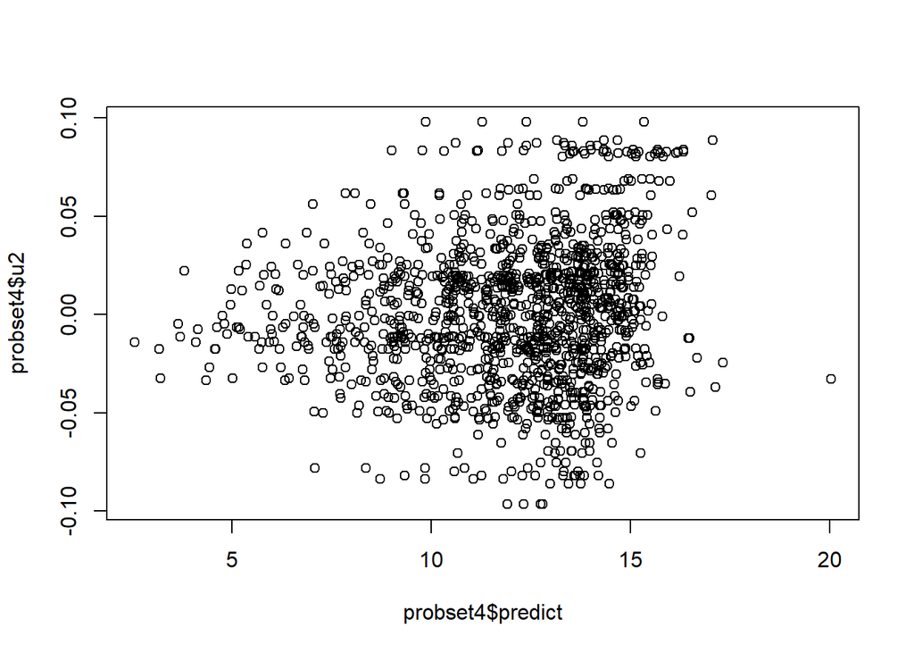

```r
plot(probset4$u2 ~ probset4$predict)
```

#### Q-Q Plot of random effects

The Q-Q plot for Level 2 residuals can be obtained from the `plot_model` function of `sjPlot`, using `type = "diag"` (“diag” meaning “diagnostic”). Specifically, the Q-Q plot is the second of four plots generated from this code. The other three plots replicate some of diagnostic plots we created above.

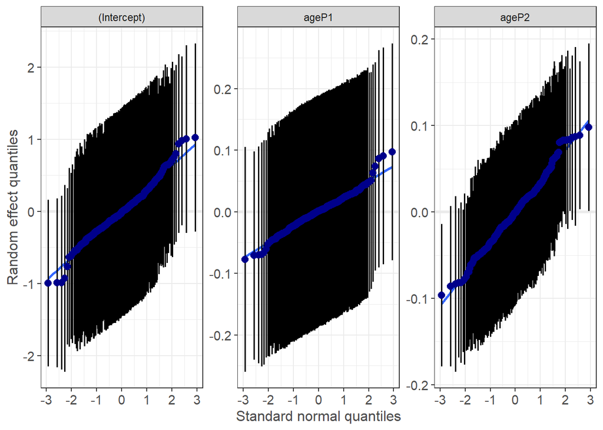

```r
diagnostic_plot <- sjPlot::plot_model(model, type = "diag")

diagnostic_plot[[2]]$ID
```

The remaining diagnostic plots can be isolated with the following code:

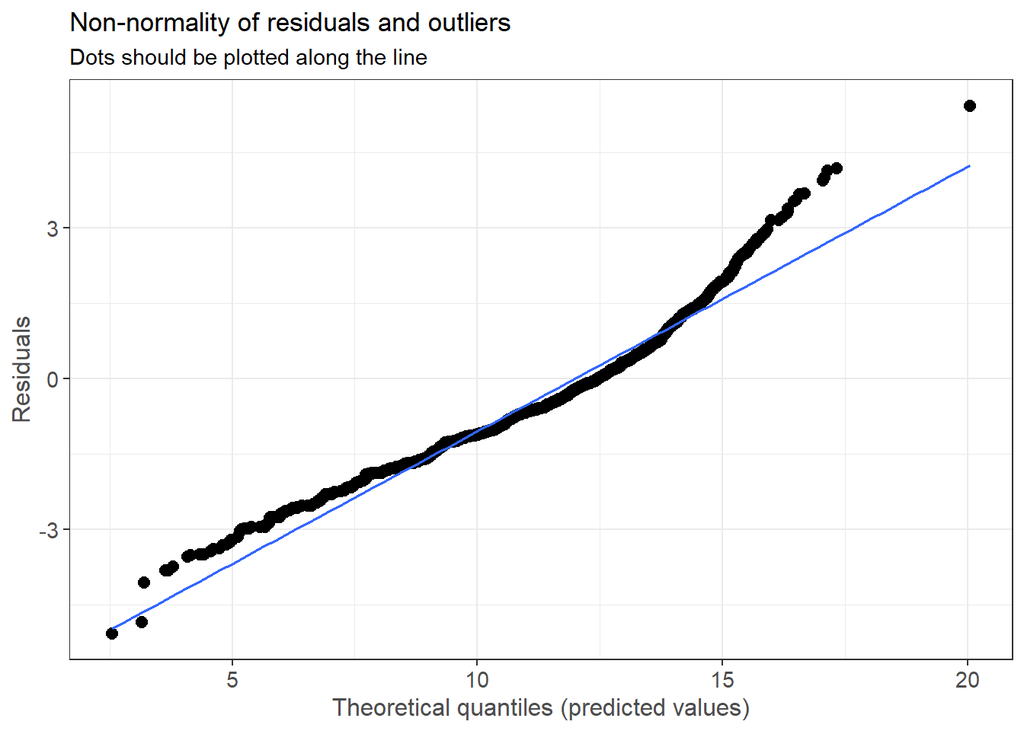

```r
diagnostic_plot[[1]]
```

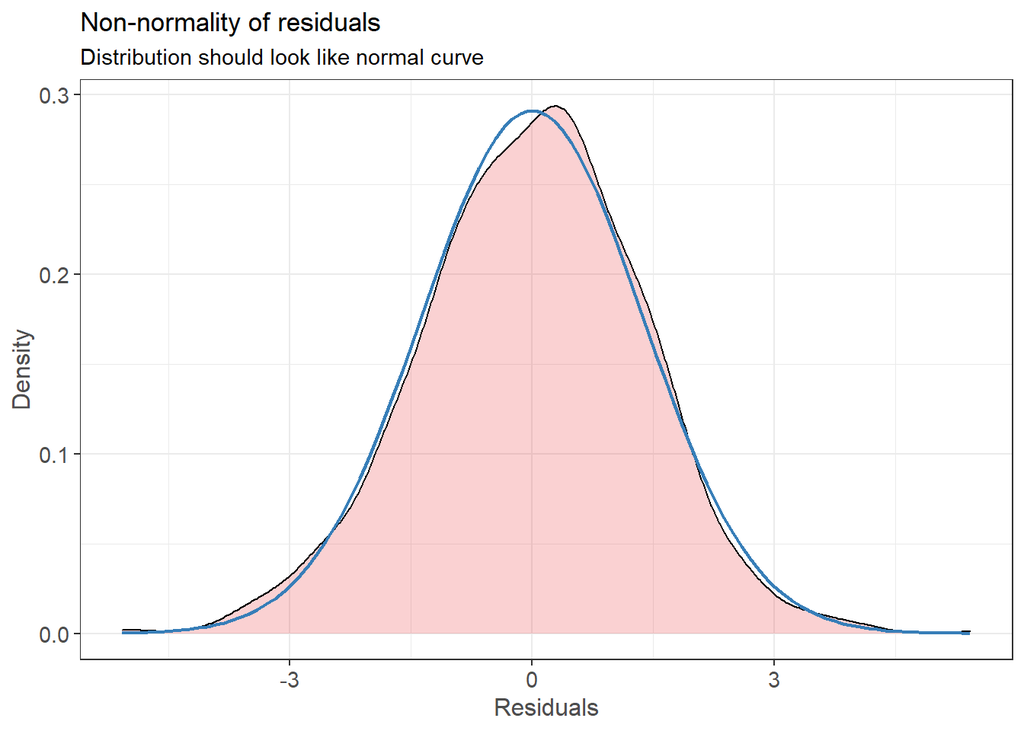

```r
diagnostic_plot[[3]]
```

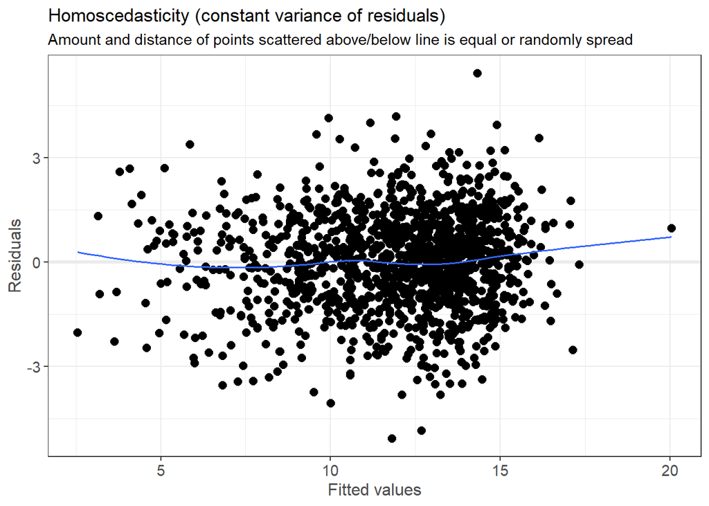

```r
diagnostic_plot[[4]]
```